# Efficacy of Prosper Score and Prosper Rating for Predicting Loan Outcome

### Borrower Rate and Prosper Score Influence on Loan Outcome

This plot shows clear indication that defaulted or charged off loans have higher borrower rate on average than loans in other statuses (past due, current, final payment in progress, completed).

As such we can conclude that borrower rate and Prosper score together can influence a loan outcome.

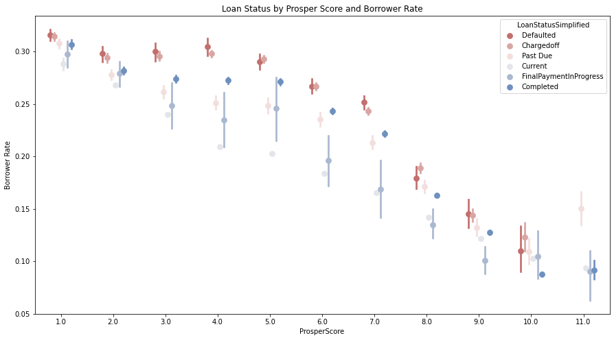

```python
# relationship among borrower rate, loan outcome, and Prosper score
fig = plt.figure(figsize = [15,8])
ax = sb.pointplot(data = loans_except_cancelled, hue = 'LoanStatusSimplified',
                  y = 'BorrowerRate', x = 'ProsperScore',
           palette = 'vlag_r', linestyles = '', dodge = 0.4)
plt.title('Loan Status by Prosper Score and Borrower Rate')
plt.ylabel('Borrower Rate')
plt.show();
```

### Debt-to-income Ratio and Prosper Score Relationship with Loan Outcome

Now let's see if there is a clear relationship among debt-to-income ratio, loan outcome, and Prosper score.

> We can see that deb-to-income ratio is higher for defaulted/charged off/past due loans compared to completed / final payment in progress score with Prosper score <= 7.0.

> Noticeably loans with Prosper score 4.0 and 6.0 have debt-to-income ratio distributed widely with probability going almost as low as completed / final payment in order loans. This observation indicates a greater risk for investors to invest in these loans because of probability of default for these loans can be larger.

> Therefore, debt-to-income ratio in conjunction with Prosper score shows clear influence on a loan outcome.

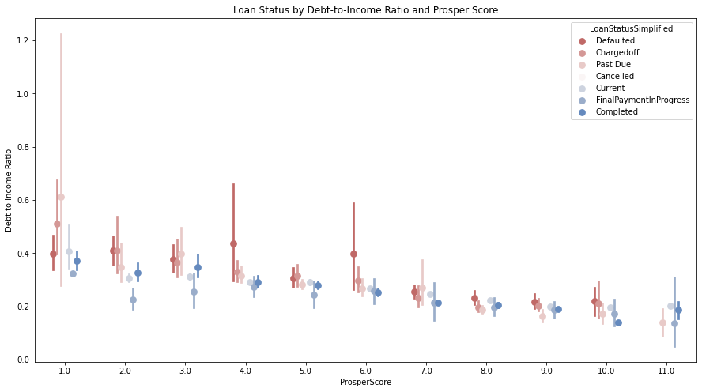

```python
# Debt-to-income Ratio and Prosper Score Relationship with Loan Outcome
fig = plt.figure(figsize = [15,8])
ax = sb.pointplot(data = loans_cleared, hue = 'LoanStatusSimplified',
                  y = 'DebtToIncomeRatio', x = 'ProsperScore',
           palette = 'vlag_r', linestyles = '', dodge = 0.4)
plt.title('Loan Status by Debt-to-Income Ratio and Prosper Score')
plt.ylabel('Debt to Income Ratio');
```

### Loan Category and Loan Amount Influence on Loan Outcome

Now let's have a look if loan category can reveal more impact on a loan outcome. The plot shows mean estimates of loan originating amount across all loan categories and will add hue for loan status.

This plot reveals that loan amount can vary a lot for some categories. We also see that loan amount for defaulted, charged off, past due can vary a lot for different categories.

However, RV and Green Loans look like top performing loan categories with clear indication that loans with higher loan amount can be more likely repaired. On the other hand, wedding or taxes loans do not provide certainty that loan will be repaid in time based on the loan amount estimate per loan status and category.

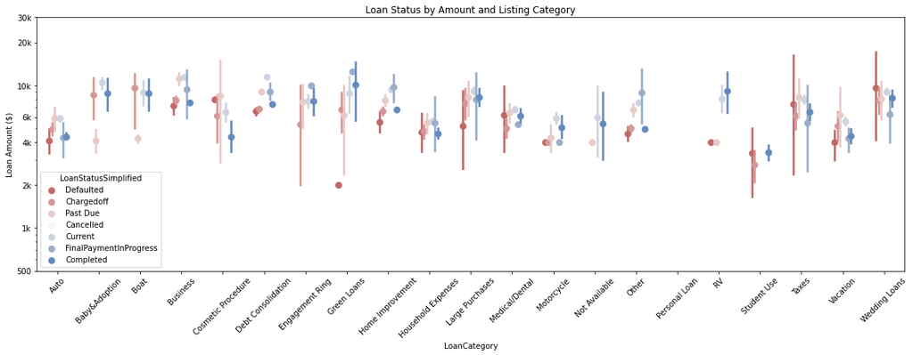

```python
# plot for loan category relationship with loan amount and loan status
fig, ax = plt.subplots(ncols = 1, figsize = [20,6])
sb.pointplot(data = loans_cleared, hue = 'LoanStatusSimplified',
             y = 'LoanOriginalAmount',
             x = 'LoanCategory', palette = 'vlag_r',
             linestyles = '', dodge = 0.4, ax = ax)
ax.set_title('Loan Status by Amount and Listing Category')
ax.set_ylabel('Loan Amount ($)')
ax.set_yscale('log')
ax.set_yticks([500, 1e3 ,2e3, 4e3, 6e3, 1e4, 2e4, 3e4])
ax.set_yticklabels(['500', '1k', '2k', '4k', '6k', '10k', '20k', '30k'])
ax.set_yticklabels([],minor = True)
plt.xticks(rotation = 45);
```

It can be a good idea to zoom in and plot each category separately across loan status, loan originating amount, and loan rating using a grid plot.

> Looking at the facets we can see that:
> - distribution of loans for each rating differs across loan categories
> - there are categories where problematic loans (defaulted / charged off / past due) are more frequent than completed / final payment in progress loans. Example is Medical/Dental category
> - interestingly we can note that vacation loans are more often become past due compared to the completed loans for this category
> - there are categories where no defaulted loans detected on the chart such as 'Engagement Ring', 'Baby Adoption', 'Boat'
> - There are categories that have loans more frequently completed than charged off. Example: Green Loans

> Overall, the plot confirms that loan category can have influence on a loan outcome.

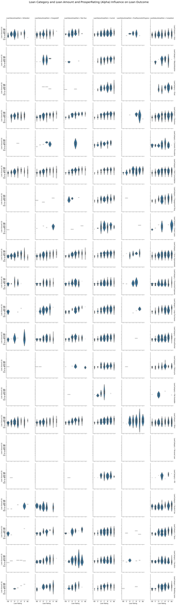

```python
# loan category vs loan rating, loan amount, loan status
#fig = plt.figure(figsize = [20,20])
g = sb.FacetGrid(data = loans_except_cancelled, col = 'LoanStatusSimplified',
                 row = 'LoanCategory',
                 height = 3, margin_titles = True,
                 row_order = loan_categories
                )
g.map(sb.violinplot, 'ProsperRating (Alpha)', 'log_loan_amt', scale='count');
g.set_xlabels('Loan Rating')
g.set_ylabels('Loan Amount ($)');
g.fig.subplots_adjust(top=0.95)
g.fig.suptitle('Loan Category and Loan Amount and ProsperRating (Alpha) Influence on Loan Outcome',
              fontsize=20);
plt.yticks(log_trans(np.array([500, 1e3 ,2e3, 4e3, 6e3, 1e4, 2e4, 3e4,9e4])),
               [500, '1k', '2k', '5k', '10k', '20k', '30k', '90k']);
```

### Employment Status Influence on Loan Outcome

To start with, I will explore relationship between employment status and Prosper score based on borrower's stated monthly income.

This plot shows that on average self-employed, employed, full-time borrowers earn more than borrowers in `other`, not employed, retired, and part-time categories.

As such, stated monthly income and employment status are driving Prosper Score which in turn drives loan outcome.

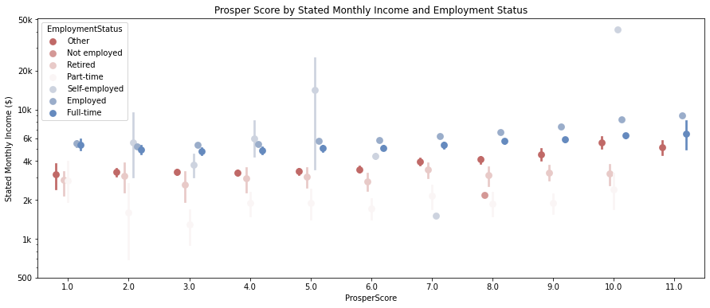

```python
# plot central tendency of stated monthly income across employment status and Prosper score
fig = plt.figure(figsize = [15,6])
ax = sb.pointplot(data = loans_except_cancelled, hue = 'EmploymentStatus',
                  y = 'StatedMonthlyIncome', x = 'ProsperScore',
           palette = 'vlag_r', linestyles = '', dodge = 0.4)
plt.title('Prosper Score by Stated Monthly Income and Employment Status')
plt.ylabel('Stated Monthly Income ($)')
plt.yscale('log')
plt.yticks([500, 1e3 ,2e3, 4e3, 6e3, 1e4, 2e4, 5e4], ['500', '1k', '2k', '4k', '6k', '10k','20k','50k'])
ax.set_yticklabels([],minor = True)
plt.show();
```

Next, we will see if loans with some employment groups are more reliable in terms of completing the repayments / pay on time.

This plot reveals interesting observation that part-time employed borrowers can default or miss a payment on a much wider loan amount spread compared to other groups.It makes sense as `ProsperScore (numeric)` has lower rating estimate for part time borrowers compared to other employment groups other than not employed as observed earlier.

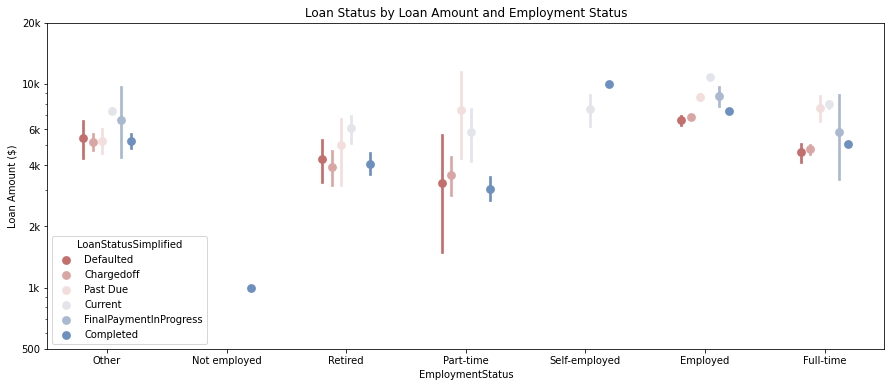

```python
# point plot for employment status, loan amount vs loan outcome
fig = plt.figure(figsize = [15,6])
ax = sb.pointplot(data = loans_except_cancelled, hue = 'LoanStatusSimplified',
                  y = 'LoanOriginalAmount', x = 'EmploymentStatus',
           palette = 'vlag_r', linestyles = '', dodge = 0.4)
plt.title('Loan Status by Loan Amount and Employment Status')
plt.ylabel('Loan Amount ($)')
plt.yscale('log')
plt.yticks([500, 1e3 ,2e3, 4e3, 6e3, 1e4, 2e4],
           ['500', '1k', '2k', '4k', '6k', '10k','20k'])
ax.set_yticklabels([],minor = True)
plt.show();
```